# H5 (revisited): Where Does a Windfall Go?

Allocation of revenue that arrives above a three-year inflation-adjusted baseline, 2019-2024

# Purpose

The original H5 (`h5-surplus-allocation.Rmd`) asked where a **surplus** goes: it regressed each balance-sheet block’s movement on the level of the surplus and read the coefficients as cents per surplus dollar. That document stands. This one asks a different and, for the index, more useful question:

**When an organization has an unusually good year, what does it do with the money?**

The difference matters because a surplus is already the residual of a decision. By the time a dollar shows up as surplus, the organization has decided not to spend it. Starting from the revenue windfall instead puts the spend-or-keep decision *inside* the estimate, which is where the interesting behaviour is. Every dollar of revenue arriving above what an organization normally raises is either spent in the same year or it is not; if it is not, it lands on the balance sheet as cash, receivables, property, investments, or debt paid down.

This is the mirror of H6. The two documents share one data preparation (`baseline-prep.R`), one population, one deflator and one baseline, so the upside and downside estimates are directly comparable — section 11 puts them in one table.

## What is inherited from the H6 rework

1. **Windfalls are measured against a trailing three-year average, not year *t-1*.** Against *t-1*, an organization recovering from one bad year looks identical to one receiving a windfall. Section 2 shows that almost a third of the year-over-year “windfalls” are exactly that.
2. **Everything is in constant 2023 dollars** (CPI-U), applied before any baseline is formed.
3. **Every channel is reported twice**: cents per dollar of windfall, and the same dollars as a share of what that channel started with. Putting 25 cents into cash and 25 cents into property is the same number twice, but it may double the cash and add 2% to the buildings.

**A windfall** is an organization-year in which total real revenue comes in at least 20% **above** the organization’s own inflation-adjusted average of the 3 prior tax years — the exact mirror of H6’s shock.

**Scaling.** Everything is divided by **baseline expenses**, the trailing three-year real average. Current-year expenses are an outcome here (spending the windfall is one of the things being measured), so they cannot be the denominator.

**Sign convention.** Throughout this document a positive number is a **use of the windfall**: spending above the normal level, an asset that grew by more than it normally does, or debt that grew by less than it normally does. On the revenue side a positive number is a **source**: a line that came in above its own baseline.

```r
suppressMessages({
  library(data.table)
  library(bit64)
  library(knitr)
})
set.seed(params$seed)
fmt <- function(x, d = 3) formatC(x, format = "f", digits = d)
pct <- function(x, d = 1) paste0(formatC(100 * x, format = "f", digits = d), "%")
BW  <- as.integer(params$base_window)
```

# 1. Data and the baseline

Blocks and revenue components are defined exactly as in H6; the tables in that document’s section 1 apply here unchanged.

```r
source("baseline-prep.R", local = knitr::knit_global())
kable(filings_by_year, format.args = list(big.mark = ","),
      caption = "Full-990 December filings available by tax year")
```

Full-990 December filings available by tax year

| TAX_YEAR | filings | organizations |
| --- | --- | --- |
| 2,016 | 98,729 | 98,729 |
| 2,017 | 106,781 | 106,781 |
| 2,018 | 115,312 | 115,312 |
| 2,019 | 128,869 | 128,869 |
| 2,020 | 128,696 | 128,696 |
| 2,021 | 128,755 | 128,755 |
| 2,022 | 128,807 | 128,807 |
| 2,023 | 128,898 | 128,898 |
| 2,024 | 113,696 | 113,696 |

```r
kable(p[, .(org_years = .N, organizations = uniqueN(EIN2)), by = year][order(year)],
      format.args = list(big.mark = ","),
      caption = "Organization-years with a complete three-year baseline")
```

Organization-years with a complete three-year baseline

| year | org_years | organizations |
| --- | --- | --- |
| 2,019 | 92,655 | 92,655 |
| 2,020 | 102,415 | 102,415 |
| 2,021 | 112,937 | 112,937 |
| 2,022 | 126,147 | 126,147 |
| 2,023 | 125,856 | 125,856 |
| 2,024 | 111,068 | 111,068 |

# 2. What a windfall looks like

```r
g <- p$gap
qs <- c(0.01, 0.10, 0.25, 0.50, 0.75, 0.90, 0.95, 0.99, 0.999)
dist <- data.table(statistic = c("median", "robust SD (IQR/1.349)", paste0("p", qs * 100)),
                   gap = round(c(median(g), iqr_sd(g), quantile(g, qs)), 4))
kable(dist, caption = "Revenue relative to a three-year inflation-adjusted baseline (0 = exactly on baseline)")
```

Revenue relative to a three-year inflation-adjusted baseline (0 = exactly on baseline)

| statistic | gap |
| --- | --- |
| median | -0.0032 |
| robust SD (IQR/1.349) | 0.2844 |
| p1 | -0.9880 |
| p10 | -0.4449 |
| p25 | -0.1806 |
| p50 | -0.0032 |
| p75 | 0.2031 |
| p90 | 0.5773 |
| p95 | 1.0210 |
| p99 | 3.4119 |
| p99.9 | 23.7768 |

```r
z20 <- (params$shock_threshold - median(g)) / iqr_sd(g)
by_size <- p[, .(organization_years = .N, median = median(gap), robust_sd = iqr_sd(gap),
                 p90 = quantile(gap, 0.90),
                 sd_of_a_20pct_windfall = (params$shock_threshold - median(gap)) / iqr_sd(gap),
                 share_windfall = mean(windfall)),
             by = size_band][order(size_band)]
kable(by_size, digits = 3, format.args = list(big.mark = ","),
      caption = "The 20% rule on the upside, by baseline revenue band")
```

The 20% rule on the upside, by baseline revenue band

| size_band | organization_years | median | robust_sd | p90 | sd_of_a_20pct_windfall | share_windfall |
| --- | --- | --- | --- | --- | --- | --- |
| under $100k | 61,737 | -0.017 | 0.561 | 1.407 | 0.387 | 0.344 |
| $100k-500k | 240,144 | -0.012 | 0.306 | 0.591 | 0.695 | 0.259 |
| $500k-2m | 204,036 | 0.001 | 0.275 | 0.541 | 0.726 | 0.253 |
| $2m-10m | 108,100 | 0.002 | 0.246 | 0.468 | 0.803 | 0.228 |
| $10m+ | 57,061 | 0.008 | 0.171 | 0.313 | 1.125 | 0.170 |

A 20% windfall sits 0.71 robust standard deviations above the median and occurs in 25.2% of organization-years — marginally *more* common than a 20% shortfall (23.3%). As on the downside, the same fixed percentage is a much weaker filter for small organizations than for large ones.

**The upside tail is far fatter than the downside tail, and this is the one place where the two sides cannot be treated symmetrically.** A shortfall is bounded: revenue cannot fall more than 100% below baseline without going negative, and only 0.34% of organization-years do. There is no corresponding ceiling.

```r
b <- c(0.5, 1, 2, 5, 10, 50)
tail_tab <- data.table(
  bound = b,
  organization_years_above = vapply(b, function(v) sum(p$gap > v), 0L),
  share_of_all = vapply(b, function(v) mean(p$gap > v), 0),
  share_of_windfalls = vapply(b, function(v) sum(p$gap > v) / sum(p$windfall), 0))
kable(tail_tab, digits = 5,
      caption = "How many organization-years come in further than a given multiple above baseline")
```

How many organization-years come in further than a given multiple above baseline

| bound | organization_years_above | share_of_all | share_of_windfalls |
| --- | --- | --- | --- |
| 0.5 | 78667 | 0.11722 | 0.46441 |
| 1.0 | 34459 | 0.05135 | 0.20343 |
| 2.0 | 13655 | 0.02035 | 0.08061 |
| 5.0 | 4056 | 0.00604 | 0.02394 |
| 10.0 | 1722 | 0.00257 | 0.01017 |
| 50.0 | 349 | 0.00052 | 0.00206 |

```r
cat("maximum gap observed:", fmt(max(p$gap), 1), "\n")
```

```
## maximum gap observed: 1279747.4
```

## Was the year-over-year rule picking up recoveries?

H6 found that a quarter of the organization-years the *t-1* rule called a shock were really the reversion leg of a windfall. The same error runs the other way here: an organization that had one bad year and returns to normal shows a large year-over-year *gain* while nothing good has happened.

```r
rec <- p[windfall_t1 == TRUE,
  .(n = .N,
    median_prior_year_vs_baseline = median(prior_windfall),
    share_prior_year_20pct_below_baseline = mean(prior_windfall < -0.20),
    median_current_vs_baseline = median(gap)),
  by = .(also_a_baseline_windfall = windfall)][order(-also_a_baseline_windfall)]
kable(rec, digits = 3,
      caption = "Organization-years the prior-year rule calls a windfall, split by whether the baseline rule agrees")
```

Organization-years the prior-year rule calls a windfall, split by whether the baseline rule agrees

| also_a_baseline_windfall | n | median_prior_year_vs_baseline | share_prior_year_20pct_below_baseline | median_current_vs_baseline |
| --- | --- | --- | --- | --- |
| TRUE | 114756 | 0.006 | 0.184 | 0.591 |
| FALSE | 51654 | -0.306 | 0.685 | 0.013 |

```r
ov <- p[, .(t1_rule = sum(windfall_t1), baseline_rule = sum(windfall),
            both = sum(windfall & windfall_t1),
            t1_only = sum(windfall_t1 & !windfall),
            baseline_only = sum(windfall & !windfall_t1))]
kable(ov, format.args = list(big.mark = ","),
      caption = "Overlap of the two windfall definitions, all years")
```

Overlap of the two windfall definitions, all years

| t1_rule | baseline_rule | both | t1_only | baseline_only |
| --- | --- | --- | --- | --- |
| 166,410 | 169,390 | 114,756 | 51,654 | 54,634 |

31.0% of the year-over-year “windfalls” are rejected by the baseline rule — a **larger** contamination than the the 25% H6 found on the loss side — and the rejected group is unmistakable: their prior year sat a median -30.6% below their own baseline, and their current year is 1.3% from it. They recovered; they did not gain.

# 3. Channels, sample and trimming

```r
# sign = +1 : actual minus baseline. sign = -1 : baseline minus actual.
# Either way a POSITIVE number is a use of the windfall (or, on the revenue
# rows, a source of it).
CH <- rbindlist(list(
  data.table(name="gov",       label="Government grants",         actual="gov",       base="base_gov",       capacity="base_gov",       sign=1, group="revenue"),
  data.table(name="dues",      label="Membership dues",           actual="dues",      base="base_dues",      capacity="base_dues",      sign=1, group="revenue"),
  data.table(name="events",    label="Fundraising events",        actual="events",    base="base_events",    capacity="base_events",    sign=1, group="revenue"),
  data.table(name="contr_oth", label="Other contributions",       actual="contr_oth", base="base_contr_oth", capacity="base_contr_oth", sign=1, group="revenue"),
  data.table(name="program",   label="Program revenue",           actual="program",   base="base_program",   capacity="base_program",   sign=1, group="revenue"),
  data.table(name="invest",    label="Investments",               actual="invest",    base="base_invest",    capacity="base_invest",    sign=1, group="revenue"),
  data.table(name="other",     label="Other revenue",             actual="other",     base="base_other",     capacity="base_other",     sign=1, group="revenue"),
  data.table(name="spend",     label="Extra spending",            actual="E",         base="base_E",         capacity="base_E",         sign=1, group="absorption"),
  data.table(name="sp_prog",   label="Program services",          actual="program_expenses",     base="base_program_expenses",     capacity="base_program_expenses",     sign=1, group="expense"),
  data.table(name="sp_admin",  label="Management and general",    actual="admin_expenses",       base="base_admin_expenses",       capacity="base_admin_expenses",       sign=1, group="expense"),
  data.table(name="sp_fund",   label="Fundraising",               actual="fundraising_expenses", base="base_fundraising_expenses", capacity="base_fundraising_expenses", sign=1, group="expense"),
  data.table(name="sp_unall",  label="Unallocated",               actual="unallocated_expenses", base="base_unallocated_expenses", capacity="base_unallocated_expenses", sign=1, group="expense"),
  data.table(name="bs_cash",   label="Cash",                      actual="d_cash",          base="base_d_cash",          capacity="boy_cash",          sign=1,  group="block"),
  data.table(name="bs_oca",    label="Receivables, prepaid",      actual="d_other_current", base="base_d_other_current", capacity="boy_other_current", sign=1,  group="block"),
  data.table(name="bs_fixed",  label="Property and equipment",    actual="d_fixed",         base="base_d_fixed",         capacity="boy_fixed",         sign=1,  group="block"),
  data.table(name="bs_othass", label="Investments, other assets", actual="d_other_assets",  base="base_d_other_assets",  capacity="boy_other_assets",  sign=1,  group="block"),
  data.table(name="bs_lt",     label="Long-term debt paid down",  actual="d_lt",            base="base_d_lt",            capacity="boy_lt",            sign=-1, group="block"),
  data.table(name="bs_st",     label="Short-term liabilities paid down", actual="d_st",     base="base_d_st",            capacity="boy_st",            sign=-1, group="block"),
  data.table(name="bs_othli",  label="Other liabilities paid down",     actual="d_other_liab", base="base_d_other_liab", capacity="boy_other_liab",   sign=-1, group="block")
))
CAP_PHRASE <- c(spend = "its normal budget", bs_cash = "the cash it held",
                bs_oca = "the receivables it held", bs_fixed = "the property it held",
                bs_othass = "the investments it held",
                bs_lt = "the long-term debt it owed", bs_st = "the short-term liabilities it owed",
                bs_othli = "the other liabilities it owed")

build_channels <- function(z) {
  z <- copy(z)
  z[, dol_gain := R - base_R][, s_gain := dol_gain / base_E]
  for (i in seq_len(nrow(CH))) {
    r <- CH[i]
    d <- if (r$sign == 1) z[[r$actual]] - z[[r$base]] else z[[r$base]] - z[[r$actual]]
    z[[paste0("dol_", r$name)]] <- d
    z[[paste0("s_",   r$name)]] <- d / z$base_E
    z[[paste0("cap_", r$name)]] <- z[[r$capacity]]
  }
  z[, dol_keep := dol_gain - dol_spend][, s_keep := dol_keep / base_E]   # the residual: kept
  z[, dol_na := d_na - base_d_na][, s_na := dol_na / base_E]
  z[]
}
p <- build_channels(p)

kable(data.table(
  check = c("revenue components sum to the windfall",
            "expense lines sum to the extra spending",
            "balance-sheet blocks sum to the extra net assets"),
  max_abs_error_dollars = c(
    p[, max(abs(dol_gov + dol_dues + dol_events + dol_contr_oth + dol_program + dol_invest + dol_other - dol_gain))],
    p[, max(abs(dol_sp_prog + dol_sp_admin + dol_sp_fund + dol_sp_unall - dol_spend))],
    p[, max(abs(dol_bs_cash + dol_bs_oca + dol_bs_fixed + dol_bs_othass + dol_bs_lt + dol_bs_st + dol_bs_othli - dol_na))])),
  digits = 6, caption = "Adding-up checks, before any trimming (constant dollars)")
```

Adding-up checks, before any trimming (constant dollars)

| check | max_abs_error_dollars |
| --- | --- |
| revenue components sum to the windfall | 0.000023 |
| expense lines sum to the extra spending | 0.000024 |
| balance-sheet blocks sum to the extra net assets | 15.963174 |

Outliers are handled by **dropping organization-years, not clipping values**, for the reason H5 and H6 both give: clipping each component separately breaks the adding-up the design rests on. Three rules apply, within year — the 1st/99th percentile of the scaled windfall, the 1st/99th of the net balance-sheet movement, and the top 1% of the largest single block movement (blocks offset each other, so an extreme swing between two of them passes the first two filters while carrying enormous leverage).

```r
trim_sample <- function(z, trim = TRUE, bound = params$max_gain) {
  if (!is.null(bound)) z <- z[gap <= bound]
  if (!trim) return(z[])
  z[, keep := {
    qg <- quantile(s_gain, c(0.01, 0.99), na.rm = TRUE)
    qa <- quantile(s_na,   c(0.01, 0.99), na.rm = TRUE)
    qb <- quantile(max_abs_blk, 0.99, na.rm = TRUE)
    s_gain >= qg[[1]] & s_gain <= qg[[2]] & s_na >= qa[[1]] & s_na <= qa[[2]] &
      max_abs_blk <= qb
  }, by = year]
  z <- z[keep == TRUE]; z[, keep := NULL]; z[]
}
windfalls <- function(years) trim_sample(p[year %in% years & windfall == TRUE])
main_w <- windfalls(2022:2023)
cat("windfall organization-years, 2022-2023:", format(nrow(main_w), big.mark = ","),
    " organizations:", format(uniqueN(main_w$EIN2), big.mark = ","), "\n")
```

```
## windfall organization-years, 2022-2023: 48,601  organizations: 39,485
```

```r
share_of_avg <- function(s, nm) mean(s[[paste0("s_", nm)]]) / mean(s$s_gain)
pct_capacity <- function(s, nm) {
  cap <- sum(s[[paste0("cap_", nm)]])
  if (!is.finite(cap) || cap <= 0) return(NA_real_)
  sum(s[[paste0("dol_", nm)]]) / cap
}
marginal <- function(s, nm) {
  f <- ols(s[[paste0("s_", nm)]], cbind(intercept = 1, gain = s$s_gain))
  c(b = f$b[["gain"]], se = f$se[["gain"]])
}
channel_table <- function(s, names_vec) {
  rbindlist(lapply(names_vec, function(nm) {
    m <- marginal(s, nm)
    data.table(channel = CH[name == nm, label],
               cents_per_dollar = share_of_avg(s, nm),
               pct_of_capacity  = pct_capacity(s, nm),
               marginal = m[["b"]], se = m[["se"]])
  }))
}
```

# 4. Where the windfall came from

```r
src <- channel_table(main_w, CH[group == "revenue", name])
kable(src, digits = 3,
      caption = "Which revenue lines came in above baseline, 2022-2023 windfalls")
```

Which revenue lines came in above baseline, 2022-2023 windfalls

| channel | cents_per_dollar | pct_of_capacity | marginal | se |
| --- | --- | --- | --- | --- |
| Government grants | 0.101 | 0.359 | 0.108 | 0.007 |
| Membership dues | 0.018 | 0.170 | 0.009 | 0.003 |
| Fundraising events | 0.053 | 0.377 | 0.065 | 0.006 |
| Other contributions | 0.388 | 0.453 | 0.571 | 0.011 |
| Program revenue | 0.320 | 0.338 | 0.133 | 0.007 |
| Investments | 0.049 | 0.696 | 0.056 | 0.005 |
| Other revenue | 0.070 | 0.287 | 0.058 | 0.006 |

```r
cat("sum of shares:", fmt(sum(src$cents_per_dollar)), "\n")
```

```
## sum of shares: 1.000
```

# 5. First-line allocation: spent or kept

The identity `revenue - expenses = surplus` means a windfall must show up either as spending above the organization’s own baseline, or as a surplus above its baseline. The two sum to exactly 1.

- **Extra spending** = actual expenses minus baseline expenses. Positive means the organization spent **more** than its own three-year norm — the windfall was used this year.
- **Kept** = the remainder, which lands on the balance sheet.

```r
sp <- share_of_avg(main_w, "spend")
kp <- mean(main_w$s_keep) / mean(main_w$s_gain)
mS <- marginal(main_w, "spend")
alloc <- data.table(
  channel = c("Extra spending (above its own baseline)",
              "Kept (carried onto the balance sheet)"),
  cents_per_dollar = c(sp, kp),
  pct_of_capacity  = c(pct_capacity(main_w, "spend"), NA_real_),
  marginal = c(mS[["b"]], 1 - mS[["b"]]),
  se = c(mS[["se"]], mS[["se"]]))
kable(alloc, digits = 3,
      caption = "Of each dollar of windfall, how much is spent in the same year vs. kept")
```

Of each dollar of windfall, how much is spent in the same year vs. kept

| channel | cents_per_dollar | pct_of_capacity | marginal | se |
| --- | --- | --- | --- | --- |
| Extra spending (above its own baseline) | 0.676 | 0.325 | 0.597 | 0.012 |
| Kept (carried onto the balance sheet) | 0.324 |  | 0.403 | 0.012 |

```r
cat("identity check, shares sum to:", fmt(sp + kp), "\n")
```

```
## identity check, shares sum to: 1.000
```

## What the extra spending buys

```r
spl <- channel_table(main_w, CH[group == "expense", name])
kable(spl, digits = 3,
      caption = "Where the extra spending goes (positive = that line came in above its baseline)")
```

Where the extra spending goes (positive = that line came in above its baseline)

| channel | cents_per_dollar | pct_of_capacity | marginal | se |
| --- | --- | --- | --- | --- |
| Program services | 0.539 | 0.318 | 0.503 | 0.011 |
| Management and general | 0.061 | 0.243 | 0.058 | 0.003 |
| Fundraising | 0.020 | 0.246 | 0.021 | 0.002 |
| Unallocated | 0.056 | 0.384 | 0.015 | 0.004 |

```r
cat("sums to the extra-spending share:", fmt(sum(spl$cents_per_dollar)), " vs. ", fmt(sp), "\n")
```

```
## sums to the extra-spending share: 0.676  vs.  0.676
```

# 6. Where the balance sheet puts it

Each block enters as its movement during the windfall year measured against its own baseline movement. An organization that normally adds $40k to cash a year and this year added $140k has parked $100k of the windfall there.

```r
bs <- channel_table(main_w, CH[group == "block", name])
kable(bs, digits = 3,
      caption = "Where the kept portion lands (positive = a use of the windfall)")
```

Where the kept portion lands (positive = a use of the windfall)

| channel | cents_per_dollar | pct_of_capacity | marginal | se |
| --- | --- | --- | --- | --- |
| Cash | 0.061 | -0.003 | 0.132 | 0.019 |
| Receivables, prepaid | 0.045 | 0.200 | 0.050 | 0.008 |
| Property and equipment | 0.062 | 0.013 | 0.080 | 0.015 |
| Investments, other assets | -0.001 | -0.050 | 0.137 | 0.020 |
| Long-term debt paid down | 0.011 | -0.060 | 0.010 | 0.010 |
| Short-term liabilities paid down | -0.003 | 0.067 | -0.014 | 0.006 |
| Other liabilities paid down | 0.064 | 0.073 | -0.065 | 0.010 |

```r
ident <- data.table(
  blocks_net = sum(bs$cents_per_dollar),
  net_assets_direct = mean(main_w$s_na) / mean(main_w$s_gain),
  kept = kp, n = nrow(main_w))
kable(ident, digits = 3,
      caption = "Identity check: blocks vs. the direct net-assets movement vs. the kept share")
```

Identity check: blocks vs. the direct net-assets movement vs. the kept share

| blocks_net | net_assets_direct | kept | n |
| --- | --- | --- | --- |
| 0.238 | 0.238 | 0.324 | 48601 |

The first two columns must agree; they are the same quantity computed two ways. The third need not — net assets also move with unrealized investment gains and donated capital, which do not pass through the surplus.

**The two columns weight organizations differently, and on this table they can disagree in sign.** `cents_per_dollar` is a ratio of means of *scaled* channels, so each organization enters in proportion to its own baseline expenses — a small organization and a large one count roughly alike. `pct_of_capacity` is a ratio of raw dollar totals, so it is dominated by the largest organizations in the sample. Cash shows the effect plainly: the cents-per-dollar figure is positive (0.061) while the aggregate capacity figure is slightly negative (-0.003). Both are correct. Read together they say that the typical organization puts a little of a windfall into cash, while the large organizations that hold most of the sector’s cash were running their balances down over 2022-2023 faster than their own baseline growth — the tail end of the COVID cash build-up. Where the two columns disagree, the cents-per-dollar figure is the behavioural one and the capacity figure is the sector aggregate.

The same caveat H6 records applies to the investments row: Part X is fair value, so that block mixes deliberate investment of the windfall with market revaluation that would have happened anyway. Read cash, receivables, property and debt as behaviour; read investments as behaviour plus the market.

# 7. Is the windfall concentrated in one revenue stream?

This is the question the rework was asked for. A windfall can arrive as one large grant or as a generally good year across every line, and there is no reason to expect those to be treated the same way.

**Measure.** For each windfall organization-year, take the seven component deviations from baseline, keep the positive ones, and compute the largest one’s share of their total. A value near 1 means essentially all of the good news came from a single stream.

```r
COMPS <- CH[group == "revenue"]
dev_mat <- vapply(COMPS$name, function(nm) p[[paste0("dol_", nm)]], numeric(nrow(p)))
pos_mat <- pmax(dev_mat, 0)
pos_tot <- rowSums(pos_mat)
# max.col rather than apply(): the same answer on 670k rows in a fraction of the time
top_idx <- max.col(pos_mat, ties.method = "first")
top_val <- pos_mat[cbind(seq_len(nrow(pos_mat)), top_idx)]
p[, top_share := ifelse(pos_tot > 0, top_val / pos_tot, NA_real_)]
p[, top_component := COMPS$label[top_idx]]
p[, concentration := factor(
  ifelse(is.na(top_share), NA_character_,
  ifelse(top_share >= params$conc_high, "single stream",
  ifelse(top_share >= params$conc_low,  "mostly one stream", "spread across lines"))),
  levels = c("single stream", "mostly one stream", "spread across lines"))]

main_w <- trim_sample(p[year %in% 2022:2023 & windfall == TRUE])   # refresh with the new columns
kable(data.table(statistic = c("p10", "p25", "median", "p75", "p90"),
                 top_component_share = round(quantile(main_w$top_share, c(.1,.25,.5,.75,.9),
                                                      na.rm = TRUE), 3)),
      caption = "Share of the windfall coming from its single largest contributing line")
```

Share of the windfall coming from its single largest contributing line

| statistic | top_component_share |
| --- | --- |
| p10 | 0.551 |
| p25 | 0.699 |
| median | 0.907 |
| p75 | 0.998 |
| p90 | 1.000 |

```r
conc <- rbindlist(lapply(levels(main_w$concentration), function(lv) {
  s <- main_w[concentration == lv]
  if (nrow(s) < 200) return(NULL)
  data.table(concentration = lv, n = nrow(s),
             median_top_share = median(s$top_share),
             windfall_vs_baseline_revenue = mean(s$dol_gain) / mean(s$base_R),
             spent = share_of_avg(s, "spend"),
             kept = mean(s$s_keep) / mean(s$s_gain),
             program_spending = share_of_avg(s, "sp_prog"),
             cash = share_of_avg(s, "bs_cash"),
             cash_pct_cap = pct_capacity(s, "bs_cash"),
             investments = share_of_avg(s, "bs_othass"),
             property = share_of_avg(s, "bs_fixed"),
             debt_paid_down = share_of_avg(s, "bs_lt") + share_of_avg(s, "bs_st"))
}))
kable(conc, digits = 3,
      caption = "Allocation by how concentrated the windfall is (cents per dollar of windfall)")
```

Allocation by how concentrated the windfall is (cents per dollar of windfall)

| concentration | n | median_top_share | windfall_vs_baseline_revenue | spent | kept | program_spending | cash | cash_pct_cap | investments | property | debt_paid_down |
| --- | --- | --- | --- | --- | --- | --- | --- | --- | --- | --- | --- |
| single stream | 24818 | 0.998 | 0.380 | 0.684 | 0.316 | 0.553 | 0.088 | -0.018 | 0.011 | 0.043 | 0.009 |
| mostly one stream | 16500 | 0.765 | 0.351 | 0.664 | 0.336 | 0.522 | 0.035 | 0.055 | -0.034 | 0.086 | 0.007 |
| spread across lines | 7283 | 0.526 | 0.367 | 0.674 | 0.326 | 0.527 | 0.019 | -0.105 | 0.033 | 0.078 | 0.003 |

**Windfalls are overwhelmingly concentrated.** The median windfall takes 91% of its good news from a single revenue line, and 51% of windfall organization-years clear the 90% bar. “A generally good year across the board” is the exception, not the rule — which is itself a reason to prefer the component view in section 8 over the pooled estimate.

**But concentration barely moves the spend-or-keep decision.** The spending share is 0.684, 0.664 and 0.674 across the three groups — flat, and not even monotonic. Whatever governs how much of a windfall gets spent, it is not how concentrated the windfall is.

Where concentration does show up is in **which** balance-sheet block takes the kept portion. Single-stream windfalls put 0.088 per dollar into cash against 0.019 for spread ones, while spread windfalls put more into property (0.078 against 0.043). That ordering is consistent with a one-off grant being parked until it is clear what it is for, while a broad-based good year is treated as durable enough to commit to buildings — but the differences are small next to the component differences in section 8, and the concentration measure is partly a proxy for which line the money arrived in, so this should not be over-read.

```r
kable(dcast(main_w[!is.na(concentration), .N, by = .(top_component, concentration)],
            top_component ~ concentration, value.var = "N", fill = 0L),
      format.args = list(big.mark = ","),
      caption = "Which line is the largest contributor, by concentration")
```

Which line is the largest contributor, by concentration

| top_component | single stream | mostly one stream | spread across lines |
| --- | --- | --- | --- |
| Fundraising events | 830 | 799 | 495 |
| Government grants | 2,316 | 2,276 | 1,071 |
| Investments | 1,012 | 750 | 394 |
| Membership dues | 549 | 378 | 246 |
| Other contributions | 9,537 | 5,599 | 2,168 |
| Other revenue | 1,405 | 1,429 | 986 |
| Program revenue | 9,169 | 5,269 | 1,923 |

# 8. Windfalls concentrated in a single revenue stream

Section 7 asks whether concentration matters. This section asks which stream.

**Definition.** A component windfall is an organization-year in which one component comes in at least 33% **above** its own three-year baseline, *and* that rise is worth at least 10% of the organization’s baseline total revenue.

**Denominator.** As in H6’s mirror section, each component is scaled by **its own rise**, not by the total windfall. When one line jumps, total revenue does not necessarily rise by as much — other lines can fall at the same time, and crowding-out of that kind is one of the things worth measuring. The three shares below sum to exactly 1:

- **Offset by other revenue falling** — the share of the rise cancelled by other lines coming in below their own baselines.
- **Spent** — the share matched by spending above baseline.
- **Kept** — the remainder, onto the balance sheet.

```r
comp_flag <- function(z, nm) {
  base_c <- z[[paste0("base_", nm)]]
  rise   <- z[[paste0("dol_", nm)]]           # actual minus baseline, in dollars
  ok <- is.finite(base_c) & is.finite(rise) & base_c > 0
  ok & (rise / base_c) >= params$comp_share & (rise / z$base_R) >= params$comp_material
}
pool  <- p[year %in% 2022:2023]
flags <- vapply(COMPS$name, function(nm) comp_flag(pool, nm), logical(nrow(pool)))
pool[, nflags := rowSums(flags)]
kable(pool[, .(organization_years = .N), by = .(component_windfalls = nflags)][order(component_windfalls)],
      format.args = list(big.mark = ","),
      caption = "How many revenue components are in windfall in the same organization-year")
```

How many revenue components are in windfall in the same organization-year

| component_windfalls | organization_years |
| --- | --- |
| 0 | 168,246 |
| 1 | 70,058 |
| 2 | 12,414 |
| 3 | 1,217 |
| 4 | 66 |
| 5 | 2 |

```r
comp_alloc <- rbindlist(lapply(seq_len(nrow(COMPS)), function(i) {
  nm <- COMPS$name[i]
  s  <- trim_sample(pool[flags[, nm]])
  if (nrow(s) < 200) return(data.table(component = COMPS$label[i], n = nrow(s)))
  rise <- mean(s[[paste0("dol_", nm)]])
  data.table(
    component = COMPS$label[i], n = nrow(s), orgs = uniqueN(s$EIN2),
    median_line_rise = median(s[[paste0("dol_", nm)]] / s[[paste0("base_", nm)]]),
    offset_by_other_revenue = 1 - mean(s$dol_gain) / rise,
    spent = mean(s$dol_spend) / rise,
    kept  = mean(s$dol_keep)  / rise,
    program_spending = mean(s$dol_sp_prog) / rise,
    cash  = mean(s$dol_bs_cash) / rise,
    cash_pct_cap = pct_capacity(s, "bs_cash"),
    investments = mean(s$dol_bs_othass) / rise,
    property = mean(s$dol_bs_fixed) / rise,
    debt_paid_down = (mean(s$dol_bs_lt) + mean(s$dol_bs_st)) / rise)
}), fill = TRUE)
kable(comp_alloc, digits = 3,
      caption = "How a windfall in each revenue component is allocated (per dollar of that line's rise)")
```

How a windfall in each revenue component is allocated (per dollar of that line’s rise)

| component | n | orgs | median_line_rise | offset_by_other_revenue | spent | kept | program_spending | cash | cash_pct_cap | investments | property | debt_paid_down |
| --- | --- | --- | --- | --- | --- | --- | --- | --- | --- | --- | --- | --- |
| Government grants | 10684 | 9113 | 1.328 | 0.230 | 0.629 | 0.141 | 0.527 | -0.103 | -0.082 | 0.067 | 0.115 | 0.025 |
| Membership dues | 2149 | 1801 | 0.821 | 0.408 | 0.512 | 0.080 | 0.318 | 0.010 | 0.005 | 0.019 | 0.019 | 0.019 |
| Fundraising events | 5437 | 4394 | 1.182 | 0.442 | 0.627 | -0.069 | 0.480 | -0.117 | -0.038 | -0.092 | 0.016 | -0.016 |
| Other contributions | 23596 | 20390 | 0.779 | 0.083 | 0.559 | 0.358 | 0.493 | -0.013 | -0.011 | -0.083 | 0.089 | 0.017 |
| Program revenue | 21850 | 17112 | 0.673 | 0.093 | 0.887 | 0.020 | 0.603 | -0.039 | -0.041 | -0.446 | -0.032 | 0.137 |
| Investments | 5694 | 5477 | 2.201 | 0.123 | 0.353 | 0.525 | 0.018 | -0.397 | -0.063 | -1.389 | 0.019 | -0.527 |
| Other revenue | 9419 | 7981 | 1.297 | 0.500 | 0.270 | 0.231 | 0.027 | -0.100 | -0.060 | -0.427 | 0.011 | -0.048 |

```r
cat("offset + spent + kept = ",
    paste(fmt(comp_alloc$offset_by_other_revenue + comp_alloc$spent + comp_alloc$kept),
          collapse = ", "), "\n")
```

```
## offset + spent + kept =  1.000, 1.000, 1.000, 1.000, 1.000, 1.000, 1.000
```

The spread across components is much wider than anything in the aggregate, and it maps onto H6’s loss-side result line for line.

- **Program revenue is spent, almost entirely.** 0.887 of a dollar of extra program revenue is matched by spending above baseline and only 0.020 is kept. H6 found the mirror: 0.85 of a *lost* program dollar was matched by cutting. Program revenue and program cost move together in both directions, which is what you would expect if they are two sides of one activity rather than a financing decision.
- **Contributed income is where discretion lives.** Other contributions keep 0.358 per dollar and government grants 0.141, against near zero for program revenue.
- **Half of some windfalls never reach the bottom line.** Other revenue is 50% offset by other lines falling, fundraising events 44%, membership dues 41%. These lines tend to move when something else is moving the other way, so the “windfall” is substantially a substitution.
- **The investments row is mechanical and should not be read as behaviour.** A windfall in the investments line is mostly realized gains on asset sales, and selling an appreciated asset is exactly what makes the investments *block* on the balance sheet fall. That is why its balance-sheet coefficient is large and negative (-1.389 per dollar): the money did not go into investments, it came out of them and reappeared as revenue. The same accounting runs through the -0.527 debt figure.

# 9. Do reserves change what happens to a windfall?

H6 found that reserves buffer a shock. The upside question is whether an organization that already holds a lot of cash banks a windfall or spends it.

```r
main_w[, reserve_group := factor(c("low", "middle", "high")[
  pmin(3L, 1L + floor(3 * (frank(months_cash_boy, ties.method = "first") - 1) / .N))],
  levels = c("low", "middle", "high"))]
res <- rbindlist(lapply(levels(main_w$reserve_group), function(gp) {
  s <- main_w[reserve_group == gp]
  data.table(reserves = gp, n = nrow(s),
             median_months_cash = median(s$months_cash_boy),
             spent = share_of_avg(s, "spend"),
             program_spending = share_of_avg(s, "sp_prog"),
             kept = mean(s$s_keep) / mean(s$s_gain),
             cash = share_of_avg(s, "bs_cash"),
             cash_pct_cap = pct_capacity(s, "bs_cash"),
             property = share_of_avg(s, "bs_fixed"),
             debt_paid_down = share_of_avg(s, "bs_lt") + share_of_avg(s, "bs_st"))
}))
kable(res, digits = 3,
      caption = "Allocation by beginning-of-year reserves (cents per dollar of windfall)")
```

Allocation by beginning-of-year reserves (cents per dollar of windfall)

| reserves | n | median_months_cash | spent | program_spending | kept | cash | cash_pct_cap | property | debt_paid_down |
| --- | --- | --- | --- | --- | --- | --- | --- | --- | --- |
| low | 16201 | 2.033 | 0.654 | 0.533 | 0.346 | 0.242 | 0.225 | 0.017 | -0.002 |
| middle | 16200 | 7.130 | 0.689 | 0.553 | 0.311 | 0.142 | 0.092 | 0.053 | 0.012 |
| high | 16200 | 19.717 | 0.681 | 0.532 | 0.319 | -0.138 | -0.091 | 0.103 | 0.010 |

# 10. Continuity with the original H5

The original H5 regressed each block’s movement on the level of the surplus, scaled by the year’s expenses, over all organization-years. Re-running that specification on this sample — with baseline expenses as the denominator, so the scaling matches the rest of this document — shows how the two framings relate.

```r
h5 <- trim_sample(p[year %in% 2022:2023], bound = NULL)
h5[, s_surplus := (R - E) / base_E]
W5 <- cbind(intercept = 1, surplus = h5$s_surplus)
BLK <- CH[group == "block"]
h5_tab <- rbindlist(lapply(seq_len(nrow(BLK)), function(i) {
  # the original H5 measured the block MOVEMENT, not its deviation from baseline
  y <- h5[[BLK$actual[i]]] / h5$base_E
  f <- ols(y, W5)
  data.table(block = BLK$label[i], cents_per_surplus_dollar = f$b[["surplus"]], se = f$se[["surplus"]])
}))
kable(h5_tab, digits = 3,
      caption = "H5-style regression: block movement on the surplus level, 2022-2023")
```

H5-style regression: block movement on the surplus level, 2022-2023

| block | cents_per_surplus_dollar | se |
| --- | --- | --- |
| Cash | 0.396 | 0.031 |
| Receivables, prepaid | 0.041 | 0.005 |
| Property and equipment | 0.178 | 0.030 |
| Investments, other assets | 0.290 | 0.021 |
| Long-term debt paid down | -0.008 | 0.005 |
| Short-term liabilities paid down | -0.004 | 0.002 |
| Other liabilities paid down | -0.002 | 0.003 |

```r
cat("asset blocks minus liability blocks:",
    fmt(sum(h5_tab$cents_per_surplus_dollar[1:4]) - sum(h5_tab$cents_per_surplus_dollar[5:7])),
    " | direct net-assets regression:", fmt(ols(h5$d_na / h5$base_E, W5)$b[["surplus"]]), "\n")
```

```
## asset blocks minus liability blocks: 0.919  | direct net-assets regression: 0.919
```

The two framings answer different questions and should not be expected to agree. The H5 coefficient says where a dollar of *surplus* sits at year end; the windfall estimate says what happens to a dollar of *revenue* that arrived above normal, most of which never becomes surplus at all.

# 11. The two tails side by side

Because the sign convention is symmetric — every channel is a deviation from the organization’s own baseline, divided by the deviation in revenue — the same code run on the shortfall sample reproduces H6 exactly. That is a check on both documents as much as a comparison.

```r
# The -1 floor is applied before the percentile trim, exactly as H6 applies it,
# so this reproduces that document's sample rather than a near neighbour of it.
short_s <- trim_sample(p[year %in% 2022:2023 & shock == TRUE & gap >= -1], bound = NULL)
two <- data.table(
  channel = c("Expenses", "Surplus / kept", "Cash", "Investments, other assets",
              "Property and equipment", "Debt"),
  per_dollar_of_windfall = c(
    sp, kp, share_of_avg(main_w, "bs_cash"), share_of_avg(main_w, "bs_othass"),
    share_of_avg(main_w, "bs_fixed"),
    share_of_avg(main_w, "bs_lt") + share_of_avg(main_w, "bs_st")),
  per_dollar_of_shortfall = c(
    share_of_avg(short_s, "spend"), mean(short_s$s_keep) / mean(short_s$s_gain),
    share_of_avg(short_s, "bs_cash"), share_of_avg(short_s, "bs_othass"),
    share_of_avg(short_s, "bs_fixed"),
    share_of_avg(short_s, "bs_lt") + share_of_avg(short_s, "bs_st")))
kable(two, digits = 3,
      caption = "A dollar above baseline vs. a dollar below it, 2022-2023 (both as a share of the deviation)")
```

A dollar above baseline vs. a dollar below it, 2022-2023 (both as a share of the deviation)

| channel | per_dollar_of_windfall | per_dollar_of_shortfall |
| --- | --- | --- |
| Expenses | 0.676 | 0.104 |
| Surplus / kept | 0.324 | 0.896 |
| Cash | 0.061 | 0.443 |
| Investments, other assets | -0.001 | 0.573 |
| Property and equipment | 0.062 | 0.109 |
| Debt | 0.007 | 0.020 |

The expense row is the asymmetry that matters for the index: the share of a windfall that is spent in the same year is several times the share of a shortfall that is matched by cutting. Good news moves spending; bad news moves the balance sheet.

# 12. Robustness

```r
wins <- list(`2019 (pre-COVID)` = 2019, `2020 (COVID)` = 2020, `2021 (relief year)` = 2021,
             `2022` = 2022, `2023` = 2023, `2024` = 2024)
by_year <- rbindlist(lapply(names(wins), function(nm) {
  s <- windfalls(wins[[nm]])
  if (nrow(s) < 200) return(NULL)
  data.table(window = nm, n = nrow(s), spent = share_of_avg(s, "spend"),
             kept = mean(s$s_keep) / mean(s$s_gain),
             cash = share_of_avg(s, "bs_cash"),
             investments = share_of_avg(s, "bs_othass"),
             property = share_of_avg(s, "bs_fixed"),
             debt_paid_down = share_of_avg(s, "bs_lt") + share_of_avg(s, "bs_st"))
}))
kable(by_year, digits = 3, caption = "Allocation by windfall year")
```

Allocation by windfall year

| window | n | spent | kept | cash | investments | property | debt_paid_down |
| --- | --- | --- | --- | --- | --- | --- | --- |
| 2019 (pre-COVID) | 16630 | 0.549 | 0.451 | 0.237 | 0.350 | 0.059 | 0.008 |
| 2020 (COVID) | 15648 | 0.416 | 0.584 | 0.489 | 0.176 | 0.041 | -0.040 |
| 2021 (relief year) | 26061 | 0.346 | 0.654 | 0.315 | 0.298 | 0.036 | 0.025 |
| 2022 | 22566 | 0.663 | 0.337 | 0.075 | -0.137 | 0.051 | 0.007 |
| 2023 | 26035 | 0.687 | 0.313 | 0.048 | 0.119 | 0.072 | 0.008 |
| 2024 | 23024 | 0.570 | 0.430 | 0.281 | 0.138 | 0.067 | 0.035 |

```r
sens <- rbindlist(lapply(list(
  list(nm = "ceiling at +1.0 (as reported)", b = 1.0, t = params$shock_threshold),
  list(nm = "ceiling at +0.5",               b = 0.5, t = params$shock_threshold),
  list(nm = "ceiling at +2.0",               b = 2.0, t = params$shock_threshold),
  list(nm = "no ceiling",                    b = NULL, t = params$shock_threshold),
  list(nm = "threshold +10%, ceiling +1.0",  b = 1.0, t = 0.10),
  list(nm = "threshold +50%, ceiling +1.0",  b = 1.0, t = 0.50)), function(a) {
  s <- trim_sample(p[year %in% 2022:2023 & gap >= a$t], bound = a$b)
  data.table(definition = a$nm, n = nrow(s), spent = share_of_avg(s, "spend"),
             kept = mean(s$s_keep) / mean(s$s_gain),
             cash = share_of_avg(s, "bs_cash"),
             property = share_of_avg(s, "bs_fixed"))
}))
kable(sens, digits = 3, caption = "Sensitivity to the ceiling and the threshold")
```

Sensitivity to the ceiling and the threshold

| definition | n | spent | kept | cash | property |
| --- | --- | --- | --- | --- | --- |
| ceiling at +1.0 (as reported) | 48601 | 0.676 | 0.324 | 0.061 | 0.062 |
| ceiling at +0.5 | 32276 | 0.741 | 0.259 | -0.021 | 0.063 |
| ceiling at +2.0 | 56222 | 0.624 | 0.376 | 0.113 | 0.065 |
| no ceiling | 61270 | 0.532 | 0.468 | 0.174 | 0.076 |
| threshold +10%, ceiling +1.0 | 70231 | 0.713 | 0.287 | 0.012 | 0.059 |
| threshold +50%, ceiling +1.0 | 16330 | 0.607 | 0.393 | 0.142 | 0.066 |

```r
alt <- rbindlist(lapply(list(
  list(nm = "3-year baseline, real (as reported)", v = "gap"),
  list(nm = "2-year baseline, real",               v = "gap2"),
  list(nm = "3-year baseline, nominal",            v = "gap_nom"),
  list(nm = "prior year only, real",               v = "gap_t1")), function(a) {
  gv  <- p[[a$v]]
  sel <- p$year %in% 2022:2023 & !is.na(gv) & gv >= params$shock_threshold
  s <- trim_sample(p[sel])
  data.table(definition = a$nm, n = nrow(s), spent = share_of_avg(s, "spend"),
             kept = mean(s$s_keep) / mean(s$s_gain), cash = share_of_avg(s, "bs_cash"))
}))
kable(alt, digits = 3, caption = "Sensitivity to how the baseline is built")
```

Sensitivity to how the baseline is built

| definition | n | spent | kept | cash |
| --- | --- | --- | --- | --- |
| 3-year baseline, real (as reported) | 48601 | 0.676 | 0.324 | 0.061 |
| 2-year baseline, real | 46392 | 0.635 | 0.365 | 0.090 |
| 3-year baseline, nominal | 76196 | 0.719 | 0.281 | -0.002 |
| prior year only, real | 44168 | 0.643 | 0.357 | 0.081 |

```r
untrimmed <- trim_sample(p[year %in% 2022:2023 & windfall == TRUE], trim = FALSE)
kable(rbindlist(lapply(list(list(nm = "trimmed", s = main_w), list(nm = "untrimmed", s = untrimmed)),
  function(a) data.table(sample = a$nm, n = nrow(a$s), spent = share_of_avg(a$s, "spend"),
                         kept = mean(a$s$s_keep) / mean(a$s$s_gain),
                         cash = share_of_avg(a$s, "bs_cash")))),
  digits = 3, caption = "Trimmed vs. untrimmed")
```

Trimmed vs. untrimmed

| sample | n | spent | kept | cash |
| --- | --- | --- | --- | --- |
| trimmed | 48601 | 0.676 | 0.324 | 0.061 |
| untrimmed | 50456 | 0.512 | 0.488 | 0.507 |

# 13. The flow figure

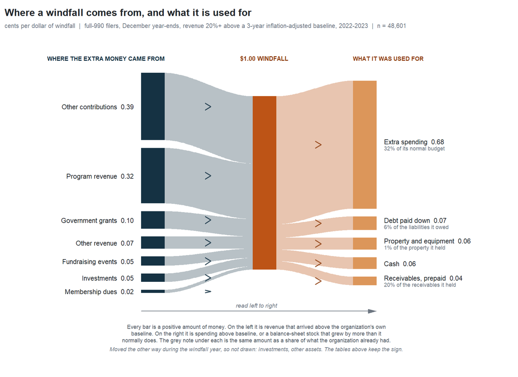

```r
pal <- c(ink = "#1f2429", ink_mid = "#4d565f", ink_soft = "#6d7681",
         accent = "#bd5416", accent_ink = "#8f3f10", navy = "#153243",
         pumpkin = "#dc965a", surface = "#f3f4f6")

flow_figure <- function(sources, uses, use_capacity_label, title, subtitle, dropped = NULL) {
  op <- par(mar = c(0.4, 0.4, 3.0, 0.4), bg = "white", family = "sans")
  on.exit(par(op))
  gap <- 0.045; centre <- 0.5
  lab_s <- sprintf("%s  %.2f", names(sources), sources)
  lab_u <- sprintf("%s  %.2f", names(uses), uses)
  sources_n <- sources / sum(sources); uses_n <- uses / sum(uses)
  half <- function(v) (sum(v) + gap * (length(v) - 1)) / 2
  top_max <- centre + max(half(sources_n), half(uses_n), 0.5)
  bot_min <- centre - max(half(sources_n), half(uses_n), 0.5)
  head_y <- top_max + 0.085; arrow_y <- bot_min - 0.105
  legend_y <- arrow_y - 0.075
  foot_y <- legend_y - (if (length(dropped)) 0.185 else 0.115)
  plot.new(); plot.window(xlim = c(0, 1), ylim = c(foot_y - 0.02, head_y + 0.06))
  stack <- function(v) {
    y <- centre + half(v)
    out <- lapply(v, function(h) { r <- c(top = y, bot = y - h); y <<- y - h - gap; r })
    names(out) <- names(v); out
  }
  ribbon <- function(x0, x1, t0, b0, t1, b1, col, alpha) {
    t <- seq(0, 1, length.out = 80); s <- t * t * (3 - 2 * t); xs <- x0 + (x1 - x0) * t
    polygon(c(xs, rev(xs)), c(t0 + (t1 - t0) * s, rev(b0 + (b1 - b0) * s)),
            col = adjustcolor(col, alpha), border = NA)
  }
  chevron <- function(x, ytop, ybot, col) {
    ymid <- (ytop + ybot) / 2; h <- min(0.020, (ytop - ybot) / 2.6); w <- 0.012
    if (h <= 0.003) return(invisible())
    lines(c(x - w, x, x - w), c(ymid + h, ymid, ymid - h), col = col, lwd = 1.6)
  }
  xs <- c(0.250, 0.300); xt <- c(0.487, 0.537); xu <- c(0.700, 0.750)
  srcb <- stack(sources_n); useb <- stack(uses_n); top <- centre + 0.5
  place <- function(boxes, minsep) {
    y <- vapply(boxes, mean, 0); n <- length(y)
    if (n > 1) for (i in (n - 1):1) if (y[i] - y[i + 1] < minsep) y[i] <- y[i + 1] + minsep
    y
  }
  ys_lab <- place(srcb, 0.052)
  yu_lab <- place(useb, if (any(nzchar(use_capacity_label))) 0.088 else 0.052)
  leader <- function(x0, x1, y_bar, y_lab, col) {
    if (abs(y_lab - y_bar) < 0.004) return(invisible())
    lines(c(x0, x1), c(y_bar, y_lab), col = adjustcolor(col, 0.45), lwd = 0.7)
  }
  cur <- top
  for (i in seq_along(srcb)) {
    ribbon(xs[2], xt[1], srcb[[i]][["top"]], srcb[[i]][["bot"]], cur, cur - sources_n[[i]],
           pal[["navy"]], 0.30)
    chevron(0.398, srcb[[i]][["top"]], srcb[[i]][["bot"]], adjustcolor(pal[["navy"]], 0.85))
    cur <- cur - sources_n[[i]]
  }
  cur <- top
  for (i in seq_along(useb)) {
    ribbon(xt[2], xu[1], cur, cur - uses_n[[i]], useb[[i]][["top"]], useb[[i]][["bot"]],
           pal[["accent"]], 0.34)
    chevron(0.632, useb[[i]][["top"]], useb[[i]][["bot"]], adjustcolor(pal[["accent_ink"]], 0.85))
    cur <- cur - uses_n[[i]]
  }
  for (i in seq_along(srcb)) {
    rect(xs[1], srcb[[i]][["bot"]], xs[2], srcb[[i]][["top"]], col = pal[["navy"]], border = NA)
    leader(xs[1] - 0.004, xs[1] - 0.012, mean(srcb[[i]]), ys_lab[i], pal[["ink_soft"]])
    text(xs[1] - 0.016, ys_lab[i], lab_s[i], adj = c(1, 0.5), cex = 0.68, col = pal[["ink"]])
  }
  rect(xt[1], centre - 0.5, xt[2], top, col = pal[["accent"]], border = NA)
  for (i in seq_along(useb)) {
    rect(xu[1], useb[[i]][["bot"]], xu[2], useb[[i]][["top"]], col = pal[["pumpkin"]], border = NA)
    leader(xu[2] + 0.004, xu[2] + 0.012, mean(useb[[i]]), yu_lab[i], pal[["ink_soft"]])
    ym <- yu_lab[i]
    if (nzchar(use_capacity_label[i])) {
      text(xu[2] + 0.016, ym + 0.018, lab_u[i], adj = c(0, 0.5), cex = 0.68, col = pal[["ink"]])
      text(xu[2] + 0.016, ym - 0.020, use_capacity_label[i], adj = c(0, 0.5), cex = 0.56,
           col = pal[["ink_soft"]])
    } else {
      text(xu[2] + 0.016, ym, lab_u[i], adj = c(0, 0.5), cex = 0.68, col = pal[["ink"]])
    }
  }
  text(xs[2], head_y, "WHERE THE EXTRA MONEY CAME FROM", adj = c(1, 0.5), cex = 0.60,
       font = 2, col = pal[["navy"]])
  text(mean(xt), head_y, "$1.00 WINDFALL", adj = c(0.5, 0.5), cex = 0.62, font = 2,
       col = pal[["accent_ink"]])
  text(xu[1], head_y, "WHAT IT WAS USED FOR", adj = c(0, 0.5), cex = 0.60, font = 2,
       col = pal[["accent_ink"]])
  lines(c(0.250, 0.740), c(arrow_y, arrow_y), col = pal[["ink_soft"]], lwd = 1)
  polygon(c(0.750, 0.732, 0.732), c(arrow_y, arrow_y + 0.013, arrow_y - 0.013),
          col = pal[["ink_soft"]], border = NA)
  text(0.495, arrow_y + 0.022, "read left to right", adj = c(0.5, 0), cex = 0.58,
       font = 3, col = pal[["ink_soft"]])
  text(0.495, legend_y,
       paste0("Every bar is a positive amount of money. On the left it is revenue that arrived above ",
              "the organization's own\nbaseline. On the right it is spending above baseline, or a ",
              "balance-sheet stock that grew by more than it\nnormally does. The grey note under each ",
              "is the same amount as a share of what the organization already had."),
       adj = c(0.5, 1), cex = 0.57, col = pal[["ink_mid"]])
  if (length(dropped)) {
    text(0.495, foot_y + 0.055,
         paste0("Moved the other way during the windfall year, so not drawn: ",
                paste(dropped, collapse = "; "), ". The tables above keep the sign."),
         adj = c(0.5, 1), cex = 0.55, col = pal[["ink_soft"]], font = 3)
  }
  mtext(title, side = 3, line = 1.45, adj = 0, cex = 1.0, font = 2, col = pal[["ink"]])
  mtext(subtitle, side = 3, line = 0.45, adj = 0, cex = 0.64, col = pal[["ink_soft"]])
}

pick <- function(v) { v <- v[v > 0.005]; sort(v, decreasing = TRUE) }
src_v  <- setNames(src$cents_per_dollar, src$channel)
uses_v <- c(`Extra spending` = sp,
            setNames(bs$cents_per_dollar, bs$channel)[
              c("Cash", "Investments, other assets", "Receivables, prepaid",
                "Property and equipment")],
            `Debt paid down` = bs[channel == "Long-term debt paid down", cents_per_dollar] +
                               bs[channel == "Short-term liabilities paid down", cents_per_dollar] +
                               bs[channel == "Other liabilities paid down", cents_per_dollar])
cap_v <- c(`Extra spending` = pct_capacity(main_w, "spend"),
           Cash = pct_capacity(main_w, "bs_cash"),
           `Investments, other assets` = pct_capacity(main_w, "bs_othass"),
           `Receivables, prepaid` = pct_capacity(main_w, "bs_oca"),
           `Property and equipment` = pct_capacity(main_w, "bs_fixed"),
           `Debt paid down` = (sum(main_w$dol_bs_lt) + sum(main_w$dol_bs_st) +
                               sum(main_w$dol_bs_othli)) /
                              sum(main_w$boy_lt + main_w$boy_st + main_w$boy_other_liab))
cap_phrase <- c(`Extra spending` = "its normal budget", Cash = "the cash it held",
                `Investments, other assets` = "the investments it held",
                `Receivables, prepaid` = "the receivables it held",
                `Property and equipment` = "the property it held",
                `Debt paid down` = "the liabilities it owed")
sources_p <- pick(src_v); uses_p <- pick(uses_v)
dropped <- c(names(src_v)[src_v <= 0.005], names(uses_v)[uses_v <= 0.005])
capk <- cap_v[names(uses_p)]
flow_figure(
  sources_p, uses_p,
  use_capacity_label = ifelse(is.na(capk) | capk <= 0, "",
                              sprintf("%.0f%% of %s", 100 * capk, cap_phrase[names(uses_p)])),
  title = "Where a windfall comes from, and what it is used for",
  subtitle = paste0("cents per dollar of windfall  |  full-990 filers, December year-ends, revenue ",
                    pct(params$shock_threshold, 0), "+ above a ", BW,
                    "-year inflation-adjusted baseline, 2022-2023  |  n = ",
                    format(nrow(main_w), big.mark = ",")),
  dropped = tolower(dropped))
```

# 14. Findings